# Coloured vowels: open data and code

## Intro

This dataset and code accompanies the following paper on categorical perception and structure in vowel-colour mappings:

> Cuskley, C.<sup>1</sup>, Dingemanse, M.<sup>1</sup>, van Leeuwen, T. & Kirby, S. 2019. Cross-modal associations and synaesthesia: Categorical perception and structure in vowel-colour mappings in a large online sample. *Behaviour Research Methods*, doi: 10.3758/s13428-019-01203-7.

<sup>1</sup> Joint first authors & corresponding authors: ccuskley@gmail.com, m.dingemanse@let.ru.nl.

## Data

The data was collected as part of a large-scale study into synaesthesia and cross-modal associations (*Groot Nationaal Onderzoek*, Van Leeuwen & Dingemanse 2016). Spoken vowel-colour association data was collected for **1164 participants** using recordings of 16 vowel sounds selected to represent points spread through acoustic vowel space (Moos et al. 2014). Grapheme-colour association data was collected for a subset of 398 participants who took a full grapheme-colour association test, among them are around 100 confirmed synaesthetes.

The focus of this paper is on colour associations to spoken vowel sounds. Data comes in the following data frames (shared in .csv and .Rdata formats): `d.voweldata` for the raw data from the association task (with `d.stimuli` recording order of presentation) and `d.participants` for anonymised participant metadata and consistency and structure scores.

- BRM_colouredvowels_voweldata.csv
- BRM_colouredvowels_stimuli.csv
- BRM_colouredvowels_participants.csv

The raw data from the association task looks like this:

```r
str(d.voweldata)
```

```
## Classes 'tbl_df', 'tbl' and 'data.frame':    18624 obs. of  9 variables:
##  $ anonid : chr  "0045dbc0-8936-4c47-b8a2-333f29f3a505" "0045dbc0-8936-4c47-b8a2-333f29f3a505" "0045dbc0-8936-4c47-b8a2-333f29f3a505" "0045dbc0-8936-4c47-b8a2-333f29f3a505" ...
##  $ setname: Factor w/ 3 levels "set1","set2",..: 1 1 1 1 1 1 1 1 1 1 ...
##  $ item   : Factor w/ 16 levels "01","02","03",..: 12 9 14 13 8 2 3 11 5 15 ...
##  $ color1 : chr  "#A82816" "#3C3899" "#9A4B37" "#963B30" ...
##  $ color2 : chr  "#B2282B" "#F44E50" "#973933" "#AE4F3F" ...
##  $ color3 : chr  "#BB322B" "#EE5A3D" "#A15042" "#8E2026" ...
##  $ timing1: num  18689 12561 10586 9186 10823 ...
##  $ timing2: num  6599 4046 4480 8701 5662 ...
##  $ timing3: num  5893 7648 9060 8250 10079 ...
```

Here, `anonid` is an anonymised participant identifier; `setname` records the item randomisation a participant was exposed to (as specified in `d.stimuli`); `item` lists item as presented in the test; and `color` and `timing` record colour choice and RT per trial (each item is presented three times).

Participant metadata is in `d.participants` and looks like this:

```r
str(d.participants)
```

```
## 'data.frame':    1164 obs. of  9 variables:
##  $ anonid        : chr  "0045dbc0-8936-4c47-b8a2-333f29f3a505" "005c48a4-acb7-4e25-8e4a-447e08a2dc85" "0086e9c0-418c-404c-8f3c-219de93cc3dc" "00879596-4a24-4341-8cc3-6a74d8efa87c" ...
##  $ age_bin       : Factor w/ 7 levels "[18,28]","(28,38]",..: 1 5 3 3 1 4 6 5 2 4 ...
##  $ genderFM      : Factor w/ 2 levels "female","male": 1 1 NA 1 1 2 1 1 1 1 ...
##  $ syn_selfreport: Factor w/ 3 levels "dunno","no","yes": 1 NA NA 1 2 2 2 1 1 2 ...
##  $ syn_status    : chr  "Syn" "NonSyn" "NonSyn" "NonSyn" ...
##  $ consistency   : num  85.1 225.3 204.8 156.5 84.7 ...
##  $ r             : num  0.7509 0.0208 -0.0154 0.1411 0.571 ...
##  $ structure     : num  8.345 0.529 -0.638 2.158 7.803 ...
##  $ p             : num  0 0.2705 0.7294 0.0366 0.0001 ...
```

The `anonid` allows linking across test results and metadata. Age, binarised gender and self-reported synaesthesia were recorded using an optional pre-test questionnaire, which about 75% of participants filled out. Age (`age_bin`) is binned to ensure participant privacy; reported age range is 18-88 (median = 46, SD = 16). Participants identifying as female are overrepresented, which is common in self-selecting online studies. In the paper, we don’t use self-reported synaesthesia in the analyses as we don’t know what types of synaesthesia people may have; instead, we compute synaesthesia based on the consistency of people’s responses across three trials in grapheme-colour and vowel-colour tasks (`syn_status`), as customary in synaesthesia research.

`consistency` is an overall measure of consistency in colour choices, based on distances in CIELuv space (lower = more consistent). 34 out of 1164 participants received no consistency score as they chose “No colour” for more than half of the items. `syn_status` is a synaesthesia classification based on the consistency score, as reported in the paper; we identified 365 synaesthetes. Finally, `r`, `structure` (also called *z score* in the paper), and `p-value` are related to the novel Structure measure we introduce in the paper, which characterizes the degree to which participants’ responses are structured isomorphically across modalities (higher = more isomorphic).

## Code

Part of our analysis is in Python. BRM_colouredvowels_MantelCode.py has the code for computing structure scores using the Mantel test.

Also, if you’re interested in the code for the online cross-modal association test, have a look at SenseTest.

## Examples

What does it look like when you ask people to associate colours to vowel sounds? Here are some samples from the data (more details in the paper).

These panels plot vowel-colour associations in vowel space, with *i* top left, *u* top right, and *a* bottom center. Each triangle represents the data for one participant. The small circles represent individual trials (randomly presented in the experiment), and each little row of three trials represents a single vowel sound (16 in total).

A key metric we introduce in the paper is *Structure*, which uses a Mantel test to measure the degree to which domains are mapped isomorphically. One finding of our study is that the associations of over two thirds of people show a significant degree of structure. These structured solutions to mapping the vowel and colour spaces are surprisingly similar across participants (whether synaesthete or not): most people pick lighter colours for [i] than for [a], and the darkest colours tend to be reserved for [o] and [u]. The patterns can be seen most clearly for participants in the upper quartile of the structure scores:

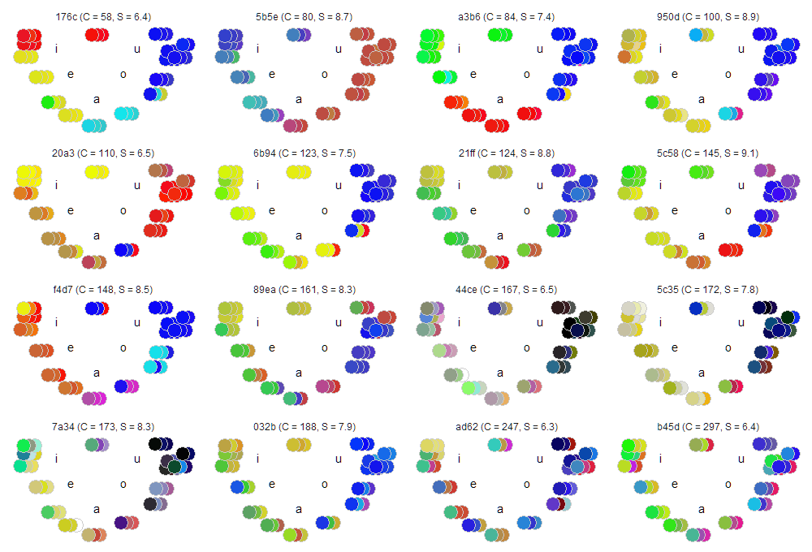

Deciding that someone has synaesthesia is usually based on a cut-off point. In the CIELuv space, which we use here, a common threshold is 135: below this, people qualify as synaesthetes. However, our Structure measure finds structured, isomorphic mappings across the board, and while there is a correlation (lower consistency scores correlate with higher structure scores) it is not clear that there is a categorical dividing line between synaesthetes and nonsynaestetes with regard to the structure of their mappings.

One reason we collected this dataset was because we are interested in the full range of diversity in cross-modal associations, from the most automatic synaesthetic concurrents to more elicited, consciously made cross-modal mappings. Dividing the data into non-synaesthetes and synaesthetes may or may not make sense depending on the data (not to mention taste, theoretical commitments or terminological preferences). This is why we make available the dataset as a whole, including all colour associations, consistency scores, and classifications based on those scores. We hope this will inform future work on the relation between cross-modal associations and synaesthesia, and on the relation between consistency and structure in synaesthetic and cross-modal associations.

## Usage

If you end up using the data or code released here, we ask you to cite the accompanying paper and link to this repository. Both are under a Creative Commons Attribution license.

Also: *there is more where this came from*. We’re already working on a few follow-up papers with large-scale data from other cross-modal tasks. But if you have a cool idea you’d like to check, or a neat analysis or visualization technique that you think would be useful for this kind of data, do get in touch with us! We’re always interested in exploring opportunities for collaboration.